# bike_sharing_trends

Eva Giannatou

June 29, 2018

# Washington DC BIKE SHARING Hands-on Assignment

## Introduction

In the last decade there have been increasing concerns regarding the environment and the quality of life, especially in big cities. In order to address these concerns, one of the measures that many cities have adopted is to provide alternative means of transportation. Hence, bike-sharing systems are becoming nowadays increasingly popular in urban environments. In addition, to the fact that the Capital Bikeshare system mitigates traffic and has a positive environmental impact, it also helps towards introducing a healthier lifestyle. People get motivated to use bicycles in their daily routine either for commuting to work or for recreational purposes. Furthermore, this new system constitutes a source of revenue for the municipality.

For all these reasons, it is crucial for the municipality to study the data obtained by the bike-sharing program from past rides, in order to better understand how to enhance participation and engagement into this new system.

## Dataset description

Capital BikeShare is a bike-sharing program located in the Washington, DC area. It has over 350 stations across the region (VA, MD, & DC), encompassing over 3,000 bikes.

For the last quarter of 2015 and 2016 (October 1 — December 31), the dataset is comprised of 1.5 million rows with 9 variables. The dataset consists of the following variables:

- Duration (s)
- Start Date
- End Date
- Start/End Station Location
- Start/End Station Number
- Bike Number
- Member Type

### Read data

```r
library(ggplot2)
library(corrplot)
library(gridExtra)
library(grid)
library(ggplot2)
library(lattice)
library(e1071)
library(dplyr)
library(tidyr)
library(purrr)
library(ggthemes)
library(cowplot)
library(ggmap)
master_df16<-read.csv('data/2016Q4-capitalbikeshare-tripdata.csv')
master_df15<-read.csv('data/2015Q4-capitalbikeshare-tripdata.csv')

master_df <- rbind(master_df16,master_df15)
```

Take a smaller random sample of the data. It will make plotting faster

```r
index = sample(1:nrow(master_df),500000,replace=FALSE)
df<-master_df[index,]
```

Factorize variables

```r
df$Start.station.number<- as.factor(df$Start.station.number)
df$End.station.number<- as.factor(df$End.station.number)
df$End.station <- as.factor(df$End.station)
df$Start.station<- as.factor(df$Start.station)
df$Bike.number<- as.factor(df$Bike.number)
df$Member.type <- as.factor(df$Member.type )
```

Convert to dates

```r
df$Start.date<- as.POSIXlt(df$Start.date)
df$End.date<- as.POSIXlt(df$End.date)
```

Create new columns

```r
# Convert duration to minutes
df$duration.min = round(df$Duration / 60, digits = 2)
library(dplyr)

# From Start.date & End.date keep [day, month, quarter, year, hour]

# start date
df$start.hour <- unclass(df$Start.date)$hour
df$start.dayofweek <-  weekdays(df$Start.date)
df$start.dayofmonth <- unclass(df$Start.date)$mday
df$start.month <- months(df$Start.date)
#df$start.quarter <- quarters(df$Start.date)
df$start.dayofyear <- unclass(df$Start.date)$yday
df$start.year <- unclass(df$Start.date)$year+1900

# End data
df$end.hour <- unclass(df$End.date)$hour
df$end.dayofweek <-  weekdays(df$End.date)
df$end.dayofmonth <- unclass(df$End.date)$mday
df$end.month <- months(df$End.date)
#df$end.quarter <- quarters(df$End.date)
df$end.dayofyear <- unclass(df$End.date)$yday
df$end.year <- unclass(df$End.date)$year+1900

# Start date day != End date day
df$returnnextday <- ifelse(df$end.dayofyear!=df$start.dayofyear, 1, 0)
df$returnnextday<- as.factor(df$returnnextday)
```

### Dataset overview

```r
str(df)
```

```
## 'data.frame':    500000 obs. of  23 variables:
##  $ Duration            : int  401 698 239 198 437 1961 1013 1364 175 636 ...
##  $ Start.date          : POSIXlt, format: "2016-12-01 18:25:28" "2016-11-08 08:23:43" ...
##  $ End.date            : POSIXlt, format: "2016-12-01 18:32:10" "2016-11-08 08:35:22" ...
##  $ Start.station.number: Factor w/ 434 levels "31000","31001",..: 137 109 23 6 165 213 182 203 285 299 ...
##  $ Start.station       : Factor w/ 434 levels "10th & E St NW",..: 89 128 182 338 333 130 93 63 117 42 ...
##  $ End.station.number  : Factor w/ 433 levels "31000","31001",..: 127 292 33 92 186 213 251 310 296 306 ...
##  $ End.station         : Factor w/ 434 levels "10th & E St NW",..: 48 190 418 374 90 130 232 105 119 332 ...
##  $ Bike.number         : Factor w/ 4421 levels "?(0x0000000074BEBCE4)",..: 222 892 2368 1652 52 1099 4309 2762 639 2379 ...
##  $ Member.type         : Factor w/ 2 levels "Casual","Member": 2 2 2 2 2 1 2 2 2 2 ...
##  $ duration.min        : num  6.68 11.63 3.98 3.3 7.28 ...
##  $ start.hour          : int  18 8 18 18 9 12 15 8 1 7 ...
##  $ start.dayofweek     : chr  "Thursday" "Tuesday" "Friday" "Tuesday" ...
##  $ start.dayofmonth    : int  1 8 28 20 17 25 12 31 22 26 ...
##  $ start.month         : chr  "December" "November" "October" "October" ...
##  $ start.dayofyear     : int  335 312 301 292 320 359 345 304 355 299 ...
##  $ start.year          : num  2016 2016 2016 2015 2015 ...
##  $ end.hour            : int  18 8 18 18 9 12 15 8 1 7 ...
##  $ end.dayofweek       : chr  "Thursday" "Tuesday" "Friday" "Tuesday" ...
##  $ end.dayofmonth      : int  1 8 28 20 17 25 12 31 22 26 ...
##  $ end.month           : chr  "December" "November" "October" "October" ...
##  $ end.dayofyear       : int  335 312 301 292 320 359 345 304 355 299 ...
##  $ end.year            : num  2016 2016 2016 2015 2015 ...
##  $ returnnextday       : Factor w/ 2 levels "0","1": 1 1 1 1 1 1 1 1 1 1 ...
```

```r
head(df)
```

```
##         Duration          Start.date            End.date
## 609591       401 2016-12-01 18:25:28 2016-12-01 18:32:10
## 423904       698 2016-11-08 08:23:43 2016-11-08 08:35:22
## 308132       239 2016-10-28 18:26:05 2016-10-28 18:30:04
## 953575       198 2015-10-20 18:38:21 2015-10-20 18:41:39
## 1202010      437 2015-11-17 09:41:23 2015-11-17 09:48:41
## 742905      1961 2016-12-25 12:11:34 2016-12-25 12:44:15
##         Start.station.number
## 609591                 31212
## 423904                 31108
## 308132                 31022
## 953575                 31005
## 1202010                31240
## 742905                 31288
##                                            Start.station
```

[output cut: 41 more lines]

### Count nulls

```r
colSums(sapply(df, is.na))
```

```
##             Duration           Start.date             End.date
##                    0                    0                    0
## Start.station.number        Start.station   End.station.number
##                    0                    0                    0
##          End.station          Bike.number          Member.type
##                    0                    0                    0
##         duration.min           start.hour      start.dayofweek
##                    0                    0                    0
##     start.dayofmonth          start.month      start.dayofyear
##                    0                    0                    0
##           start.year             end.hour        end.dayofweek
##                    0                    0                    0
##       end.dayofmonth            end.month        end.dayofyear
##                    0                    0                    0
##             end.year        returnnextday
##                    0                    0
```

### EDA

```r
plotHist <- function(data_in, i) {
  data <- data.frame(x=data_in[[i]])
  p <- ggplot(data=data, aes(x=factor(x))) + stat_count() + xlab(colnames(data_in)[i]) + theme_light() +
    theme(axis.text.x = element_text(angle = 90, hjust =1))
  return (p)
}

doPlots <- function(data_in, fun, ii, ncol=3) {
  pp <- list()
  for (i in ii) {
    p <- fun(data_in=data_in, i=i)
    pp <- c(pp, list(p))
  }
  do.call("grid.arrange", c(pp, ncol=ncol))
}

plotDen <- function(data_in, i){
  data <- data.frame(x=data_in[[i]], Duration = data_in$Duration)
  p <- ggplot(data= data) + geom_line(aes(x = x), stat = 'density', size = 1,alpha = 1.0) +
    xlab(paste0((colnames(data_in)[i]), '\n', 'Skewness: ',round(skewness(data_in[[i]], na.rm = TRUE), 2))) + theme_light()
  return(p)

}

# split dataframe into numeric and categorical columns
nums.only <- sapply(df,class)!='factor'
cat.only <- sapply(df,class)=='factor'
nums <- df[ , nums.only]
cat <- df[ , cat.only]
```

NUmber of members vs number of casual users

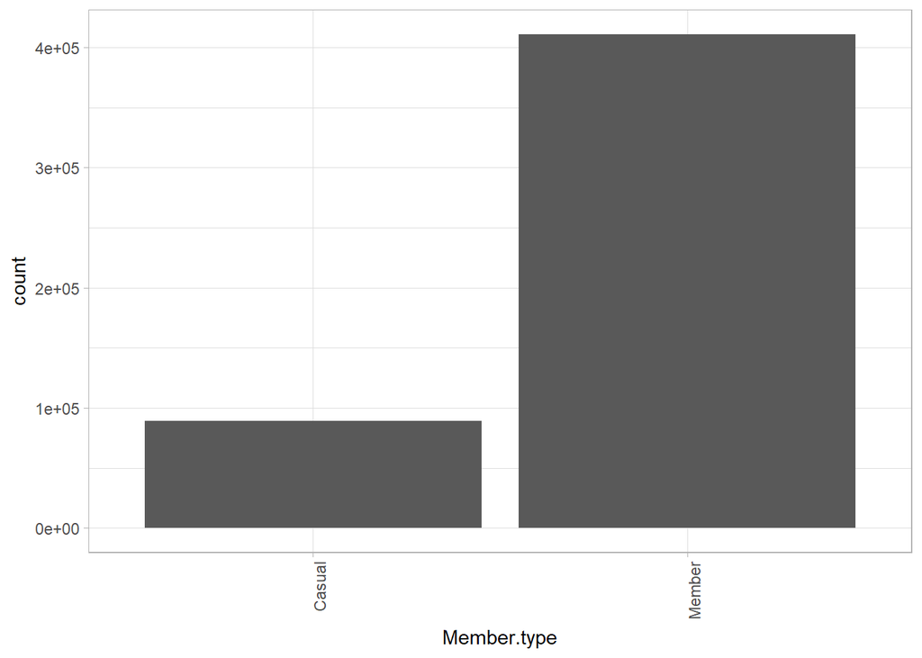

```r
doPlots(cat, fun = plotHist, ii = 6, ncol = 1)
```

Plot numeric distribution of numeric columns

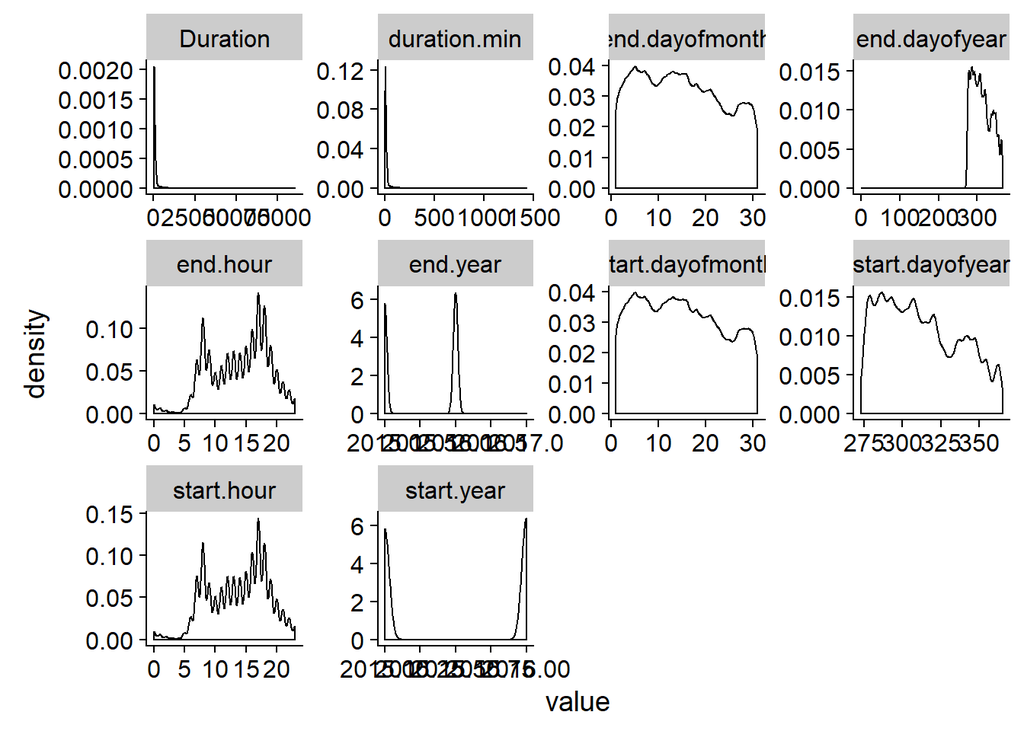

```r
df %>%
  keep(is.numeric) %>%                     # Keep only numeric columns
  gather() %>%                             # Convert to key-value pairs
  ggplot(aes(value)) +                     # Plot the values
  facet_wrap(~ key, scales = "free") +   # In separate panels
  geom_density()
```

### Data aggregation

```r
df$Start.date<- as.POSIXct(df$Start.date)
df$End.date<- as.POSIXct(df$End.date)

names(df)
```

```
##  [1] "Duration"             "Start.date"           "End.date"
##  [4] "Start.station.number" "Start.station"        "End.station.number"
##  [7] "End.station"          "Bike.number"          "Member.type"
## [10] "duration.min"         "start.hour"           "start.dayofweek"
## [13] "start.dayofmonth"     "start.month"          "start.dayofyear"
## [16] "start.year"           "end.hour"             "end.dayofweek"
## [19] "end.dayofmonth"       "end.month"            "end.dayofyear"
## [22] "end.year"             "returnnextday"
```

```r
df %>%
  group_by(start.year ,start.month, start.dayofweek, start.hour, Member.type) %>%
  summarise(
    total.rides = n(),
    avg.duration = mean(duration.min)
  ) -> aggdata

head(aggdata)
```

```
## # A tibble: 6 x 7
## # Groups:   start.year, start.month, start.dayofweek, start.hour [3]
##   start.year start.month start.dayofweek start.hour Member.type
##        <dbl> <chr>       <chr>                <int> <fct>
## 1       2015 December    Friday                   0 Casual
## 2       2015 December    Friday                   0 Member
## 3       2015 December    Friday                   1 Casual
## 4       2015 December    Friday                   1 Member
## 5       2015 December    Friday                   2 Casual
## 6       2015 December    Friday                   2 Member
## # ... with 2 more variables: total.rides <int>, avg.duration <dbl>
```

Calculate the average ride duration per year and per month

```r
avgDuration<-df %>%
  group_by(start.year, start.month) %>%
  summarize(duration.min = mean(duration.min))

avgDuration
```

```
## # A tibble: 6 x 3
## # Groups:   start.year [?]
##   start.year start.month duration.min
##        <dbl> <chr>              <dbl>
## 1       2015 December            15.1
## 2       2015 November            15.8
## 3       2015 October             16.8
## 4       2016 December            14.3
## 5       2016 November            17.2
## 6       2016 October             18.9
```

Count the number of rides per year and per month

```r
rideNo<-df %>%
  group_by(start.year, start.month) %>%
  tally %>% arrange(desc(n))
# divide (number of month rides)/(number of total rides)
rideNo$percent.rides <- rideNo$n/nrow(df)

rideNo
```

```
## # A tibble: 6 x 4
## # Groups:   start.year [2]
##   start.year start.month      n percent.rides
##        <dbl> <chr>        <int>         <dbl>
## 1       2016 October     116371         0.233
## 2       2015 October      98130         0.196
## 3       2016 November     87834         0.176
## 4       2015 November     76904         0.154
## 5       2015 December     63452         0.127
## 6       2016 December     57309         0.115
```

```r
ridesyearmonth <- merge(avgDuration, rideNo, by=c("start.year","start.month"))
ridesyearmonth
```

```
##   start.year start.month duration.min      n percent.rides
## 1       2015    December     15.06314  63452      0.126904
## 2       2015    November     15.75948  76904      0.153808
## 3       2015     October     16.83357  98130      0.196260
## 4       2016    December     14.27136  57309      0.114618
## 5       2016    November     17.16368  87834      0.175668
## 6       2016     October     18.85876 116371      0.232742
```

Count the number of rides per day and per hour

```r
df %>%
  group_by(start.dayofweek, start.hour, Member.type) %>%
  summarise(
    total.rides = n(),
    avg.duration = mean(duration.min)
  ) -> day_hour_rides

day_hour_rides
```

```
## # A tibble: 336 x 5
## # Groups:   start.dayofweek, start.hour [?]
##    start.dayofweek start.hour Member.type total.rides avg.duration
##    <chr>                <int> <fct>             <int>        <dbl>
##  1 Friday                   0 Casual              105        27.3
##  2 Friday                   0 Member              465        11.5
##  3 Friday                   1 Casual               67        37.0
##  4 Friday                   1 Member              264        11.4
##  5 Friday                   2 Casual               39        21.3
##  6 Friday                   2 Member              103        10.4
##  7 Friday                   3 Casual                9        21.3
##  8 Friday                   3 Member               46         9.39
##  9 Friday                   4 Casual               14        31.9
## 10 Friday                   4 Member               61        12.8
## # ... with 326 more rows
```

```r
# Create a subset just for the time heatmap
day_hour_rides %>%
  ungroup() %>%
  select(start.hour, start.dayofweek, total.rides, avg.duration) %>%
  mutate(total_duration = total.rides * avg.duration,
         hour = factor(start.hour, levels = (0:23))) %>%
  group_by(start.hour, start.dayofweek) %>%
  summarise(count.rides = sum(total.rides), total.duration = sum(total_duration)) -> df.1

df.1
```

```
## # A tibble: 168 x 4
## # Groups:   start.hour [?]
##    start.hour start.dayofweek count.rides total.duration
##         <int> <chr>                 <int>          <dbl>
##  1          0 Friday                  570           8204
##  2          0 Monday                  246           3013
##  3          0 Saturday                872          15806
##  4          0 Sunday                  933          14312
##  5          0 Thursday                381           5615
##  6          0 Tuesday                 271           3422
##  7          0 Wednesday               426           7417
##  8          1 Friday                  331           5483
##  9          1 Monday                  103           1625
## 10          1 Saturday                621           9369
## # ... with 158 more rows
```

Plot count of rides and ride duration of members and casual users

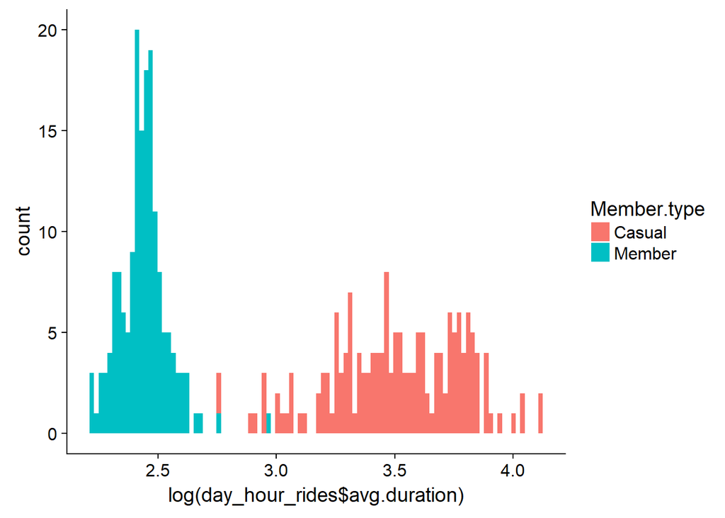

```r
g1 <- ggplot(data=day_hour_rides)
g1 + geom_histogram(mapping = aes(log(day_hour_rides$avg.duration), fill =  Member.type), bins = 100) -> g2
g1 + geom_histogram(mapping = aes(log(day_hour_rides$total.rides), fill =  Member.type), bins = 100) -> g3

plot_grid(g2)
```

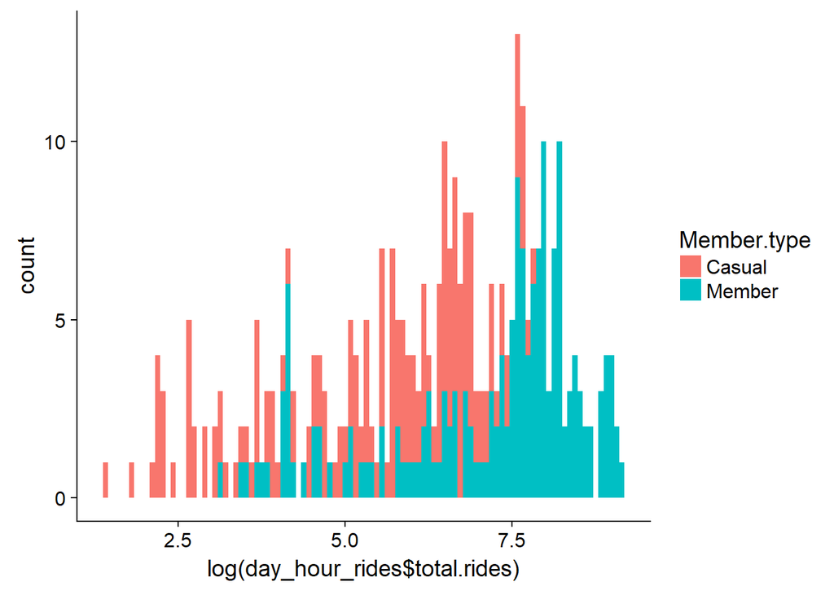

```r
plot_grid(g3)
```

More EDA plots

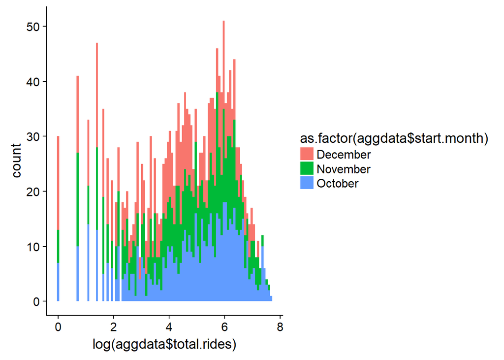

```r
df %>%
  group_by(start.month, Member.type) %>%
  summarise(
    total.rides = n(),
    avg.duration = mean(duration.min)
  ) -> month

g4 <- ggplot(data=aggdata)
g4 + geom_histogram(mapping = aes(log(aggdata$total.rides), fill = as.factor(aggdata$start.month)), bins = 100) -> g5
g4 + geom_histogram(mapping = aes(log(aggdata$avg.duration), fill = as.factor(aggdata$start.month)), bins = 100) -> g6
g4 + geom_histogram(mapping = aes(log(aggdata$total.rides), fill = as.factor(aggdata$start.year)), bins = 100) -> g7
g4 + geom_histogram(mapping = aes(log(aggdata$avg.duration), fill = as.factor(aggdata$start.year)), bins = 100) -> g8

plot_grid(g5)
```

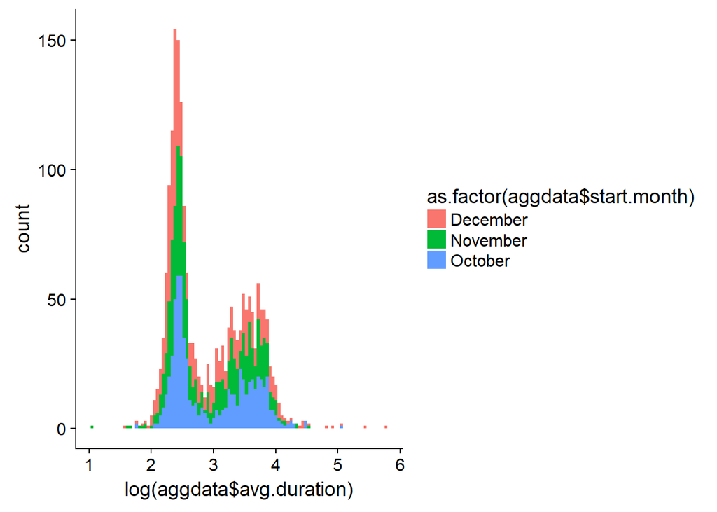

```r
plot_grid(g6)
```

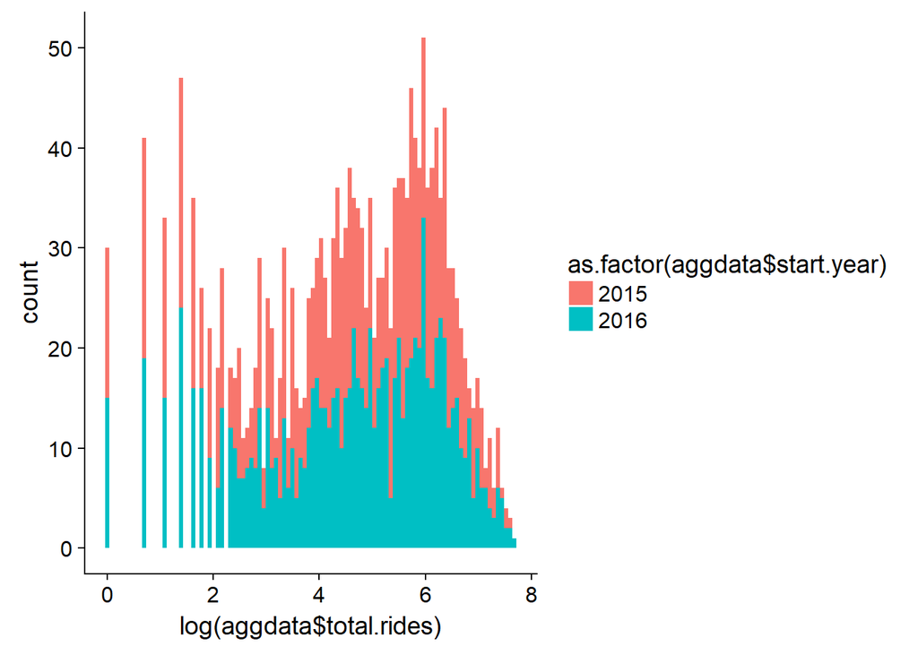

```r
plot_grid(g7)
```

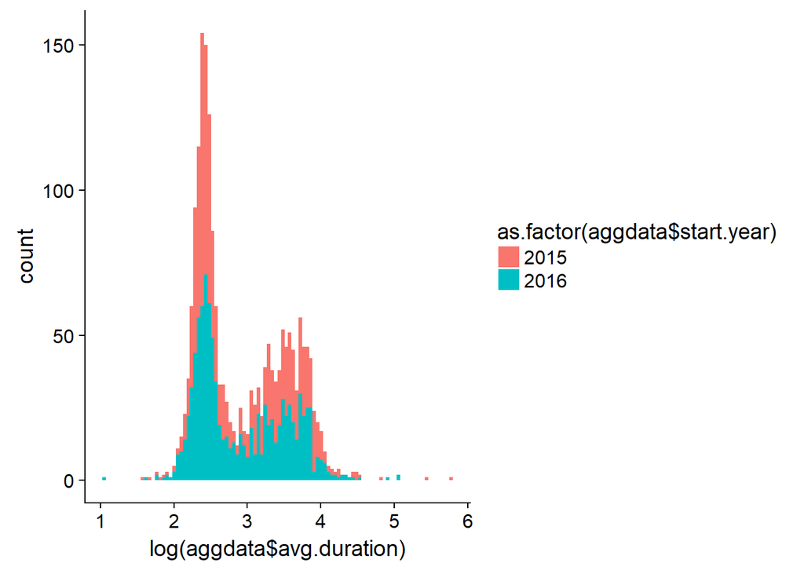

```r
plot_grid(g8)
```

Ride ditribution and duration trends thoughout the days of the week and the hours of the day

[output not shown]

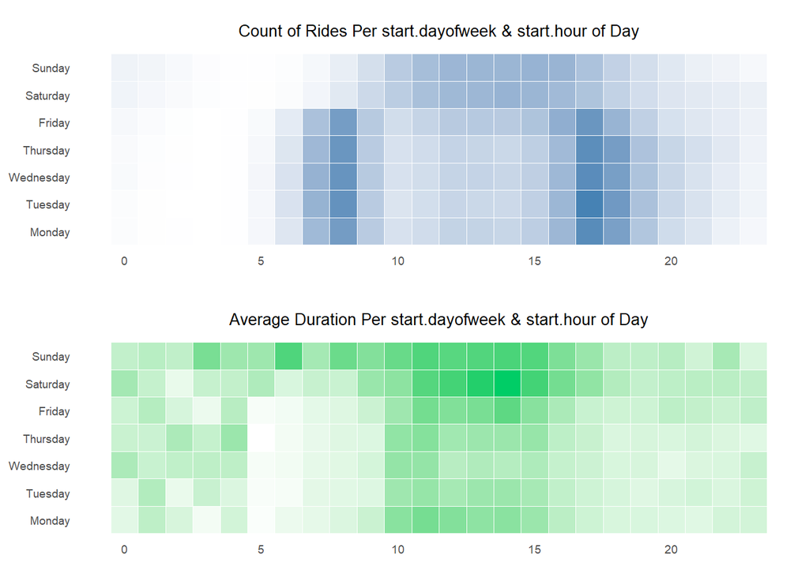

```r
df.1$start.dayofweek  = factor(df.1$start.dayofweek, levels=c("Monday", "Tuesday", "Wednesday","Thursday", "Friday", "Saturday", "Sunday"))

# Create time based heatmaps
g100 <- ggplot(data=df.1, aes(x=start.hour, y=start.dayofweek, fill=count.rides)) +
  geom_tile(color="white", size=0.1)+ coord_equal() +
  labs(x=NULL, y=NULL, title="Count of Rides Per start.dayofweek & start.hour of Day") +
  theme_tufte(base_family="Calibri") + theme(plot.title=element_text(hjust=0.5, size = 10)) +
  theme(axis.ticks=element_blank()) + theme(axis.text=element_text(size=7)) + theme(legend.position="none") +
  scale_fill_gradient(low = "white", high = "steelblue")
g101 <- ggplot(data=df.1, aes(x=start.hour, y=start.dayofweek, fill=total.duration)) +
  geom_tile(color="white", size=0.1)+ coord_equal() +
  labs(x=NULL, y=NULL, title="Total Duration Per start.dayofweek & start.hour of Day") +
  theme_tufte(base_family="Calibri") + theme(plot.title=element_text(hjust=0.5, size = 10)) + theme(legend.position="none") +
  theme(axis.ticks=element_blank()) + theme(axis.text=element_text(size=7)) +
  scale_fill_gradient(low = "white", high = "firebrick")
g102 <- ggplot(data=df.1, aes(x=start.hour, y=start.dayofweek, fill=total.duration/count.rides)) +
  geom_tile(color="white", size=0.1)+ coord_equal() +
  labs(x=NULL, y=NULL, title="Average Duration Per start.dayofweek & start.hour of Day") +
  theme_tufte(base_family="Calibri") + theme(plot.title=element_text(hjust=0.5, size = 10)) + theme(legend.position="none") +
  theme(axis.ticks=element_blank()) + theme(axis.text=element_text(size=7)) +
  scale_fill_gradient(low = "white", high = "springgreen3")
plot_grid(g100, g102, nrow = 2, rel_heights = c(1/2, 1/2))
```

### Plot most popular stations on the map

[figure not shown]

```r
address<-rbind(master_df16,master_df15)

# read a new dataset containing the coordinates of the bike stations
coord<-read.table("data/Capital_Bike_Share_Locations.csv", header = TRUE, sep = ',', quote = "", stringsAsFactors = FALSE)
coord$LATITUDE<-signif(coord$LATITUDE,digits=10)
coord$LONGITUDE<-signif(coord$LONGITUDE,digits=10)

map_df <- merge(address, coord[ , c("LATITUDE", "LONGITUDE", "TERMINAL_NUMBER")], by.x=c("Start.station.number"), by.y=c("TERMINAL_NUMBER"))

map_df$duration.min = round(map_df$Duration / 60, digits = 2)
map_df$LATITUDE<-signif(map_df$LATITUDE,digits=10)
map_df$LONGITUDE<-signif(map_df$LONGITUDE,digits=10)
# Create station list with coordinates, total count of rides, and total duration of rides
map.stations <- map_df %>%
  group_by(Start.station) %>%
  summarise(total.rides = n(),
            avg.duration = mean(duration.min),
            subscriber.percentage = mean(Member.type == "Member"),
            lat = first(LATITUDE),
            lon = first(LONGITUDE)
  )

map.stations$lat<-signif(map.stations$lat,digits=10)
map.stations$lon<-signif(map.stations$lon,digits=10)

# download basic map layers for plotting
base.map <- qmap("Wasington DC", zoom = 12, source= "google", maptype="roadmap", color = "bw", crop=FALSE, legend='topleft')
base.map.1 <- qmap("Wasington DC", zoom = 13, source= "google", maptype="roadmap", color = "bw", crop=FALSE, legend='topleft')
base.map.2 <- qmap("Wasington DC", zoom = 14, source= "google", maptype="roadmap", color = "bw", crop=FALSE, legend='topleft')
base.map + geom_point(aes(x = lon, y = lat, size=total.rides, color=avg.duration), data = map.stations,
                      alpha = .5)+ scale_size(range = c(1, 5)) + scale_colour_gradient(low = "purple", high = "red")
```

### Create ride density maps

[figure not shown]

```r
base.map.2 + geom_density2d(data = map_df[sample(1:nrow(map_df), 10000),],
                            aes(x = LONGITUDE, y = LATITUDE), size = 0.5) + stat_density2d(data = map_df[sample(1:nrow(map_df), 10000),],
                                                                                           aes(x = LONGITUDE, y = LATITUDE, fill = ..level.., alpha = ..level..), size = 3,
                                                                                           bins = 30, geom = "polygon", contour = TRUE) + scale_fill_gradient(low = "springgreen", high = "red") +
  scale_alpha(range = c(0, 0.3), guide = FALSE)
```

[figure not shown]

```r
# Create a subsliced ridership set of 15000 observations
ride_df.sample <- map_df[sample(1:nrow(map_df), 100000),]
ride_df.sample$Start.date<- as.POSIXlt(ride_df.sample$Start.date)
ride_df.sample$start.month <- months(ride_df.sample$Start.date)

# Create base layers for faceted mapping
dc.3 <- get_map('washington dc', zoom = 14, source = "google", maptype = "roadmap", crop=FALSE, color="bw")
dc.map.3 <- ggmap(dc.3, base_layer = ggplot(aes(x = LONGITUDE, y = LATITUDE), data = ride_df.sample))
# Ride frequency heatmap by month
dc.map.3 + stat_density2d(aes(x=LONGITUDE, y=LATITUDE, fill=..level.., alpha=..level..),
                          bins=7, geom="polygon", data=ride_df.sample) +
  scale_fill_gradient(low="springgreen", high="tomato") + scale_alpha(range = c(0.1, 0.6), guide = FALSE) +
  facet_wrap(~start.month, nrow = 1) +
  guides(fill=guide_legend(title="ride\nfrequency")) +
  ggtitle("Ride Distribution by Month") +
  theme(axis.title=element_blank(),
        axis.text=element_blank(),
        axis.ticks=element_blank(),
        legend.text = element_blank(),
        plot.title = element_text(color="black", size=16, hjust=0)) -> g13
g13
```

### Ride distribution per day and per hour

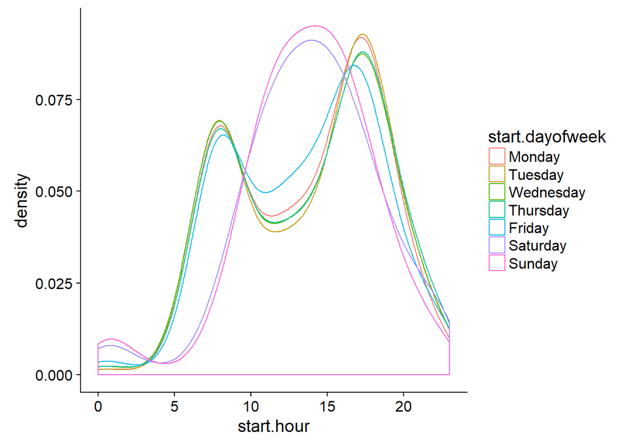

```r
df$start.dayofweek  = factor(df$start.dayofweek, levels=c("Monday", "Tuesday", "Wednesday","Thursday", "Friday", "Saturday", "Sunday"))

ggplot(data = df) +
  geom_density(aes(x = start.hour, color = start.dayofweek), adjust = 3)
```

### Ride distribution per day of the year

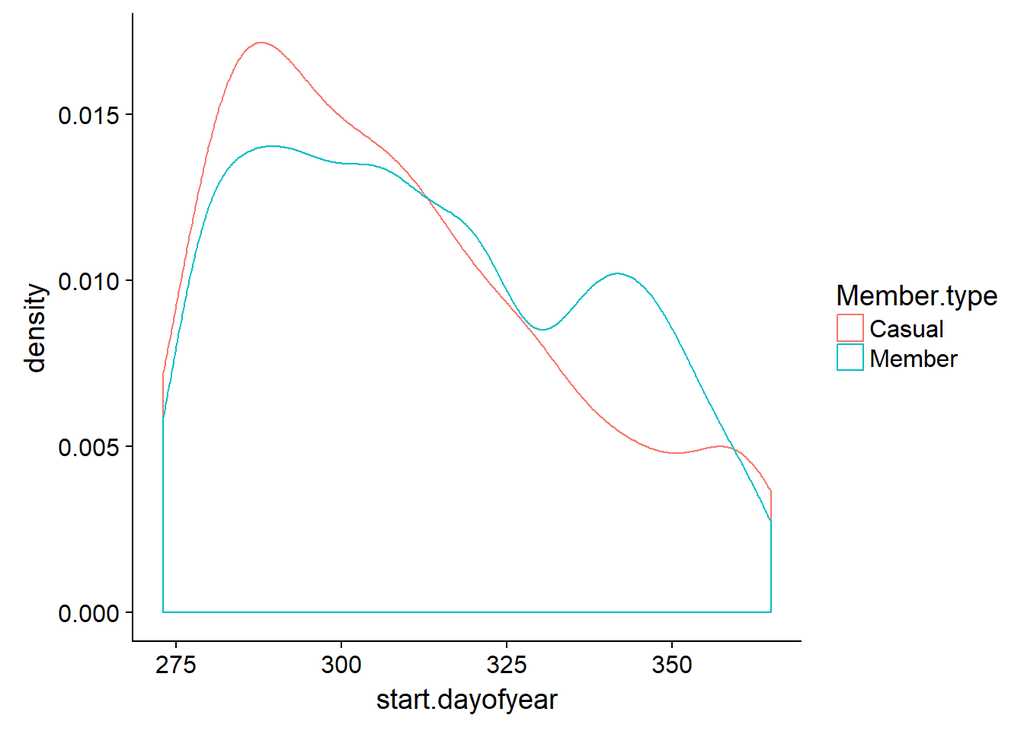

```r
ggplot(data = df) +
  geom_density(aes(x = start.dayofyear, color =Member.type), adjust = 3)
```

### Ride distribution per day of the month

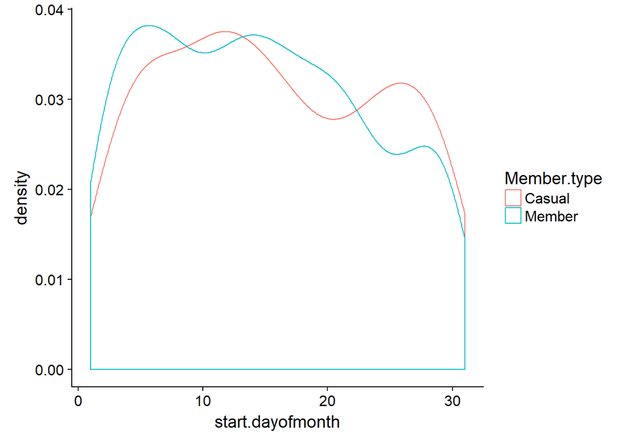

```r
ggplot(data = df) +
  geom_density(aes(x = start.dayofmonth, color =Member.type), adjust = 3)
```

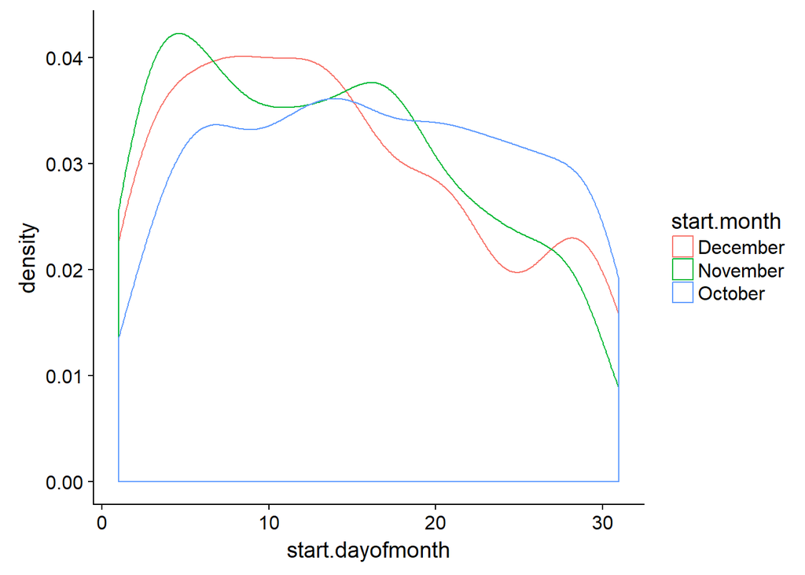

```r
ggplot(data = df) +
  geom_density(aes(x = start.dayofmonth, color =start.month), adjust = 3)
```